# MSCA 32003 Assignment 3

Wilson McDermott, Samantha Patil, and Oluwafemi Fabiyi with starter code provided by Anil D. Chaturvedi

3/01/2021

Use the starter code provided to pull tweets given keywords. Get your own Twitter credentials.

## Question One - Three

1. Choose any product category of your choice. Download Twitter data for all the leading brands in that product category.
2. Generate Document-Term-Frequency matrices (either TDF, DTF, TFIDF) after pre-processing data for stop word removal, special character removal, number removal, and case conversion.
3. Generate Wordclouds for each of the Brands separately. Do they reveal anything? Summarize insights.

```r
InstallAndLoadPackages<-function(x) {
  x <- as.character(x)
  if (!require(x,character.only=TRUE))
    {
      install.packages(pkgs=x,repos="http://cran.r-project.org")
      require(x,character.only=TRUE)
   }
}
PrepareTwitter<-function() {
  InstallAndLoadPackages("bitops")
  InstallAndLoadPackages("RCurl")
  InstallAndLoadPackages("RJSONIO")
  InstallAndLoadPackages("ROAuth")
  InstallAndLoadPackages("SnowballC")
  InstallAndLoadPackages("modeest")
  InstallAndLoadPackages("tm")
  InstallAndLoadPackages("rJava")
  InstallAndLoadPackages("RWeka")
  InstallAndLoadPackages("RWekajars")
  InstallAndLoadPackages("stopwords")
  InstallAndLoadPackages("twitteR")
  InstallAndLoadPackages("wordcloud")
  InstallAndLoadPackages("tidytext")
  InstallAndLoadPackages("topicmodels")
}
PrepareTwitter()
```

[output not shown]

[output not shown]

[output not shown]

[output not shown]

[output not shown]

[output not shown]

[output not shown]

[output not shown]

[output not shown]

```r
TweetFrame<-function(searchTerm,n,SINCE) {
  # This function TweetFrame() - Return a dataframe based on a search of Twitter
  tweetList <- searchTwitter(searchTerm,n,since=SINCE,lang='en')
  # as.data.frame() coerces each list element into a row
  # lapply() applies this to all of the elements in twtList
  # rbind() takes all of the rows and puts them together
  # do.call() gives rbind() all rows as individual elements
  tweetDF<- do.call("rbind", lapply(tweetList,as.data.frame))
  # This last step sorts the tweets in arrival order
  return(tweetDF[order(as.integer(tweetDF$created)), ])
}
```

```r
setup_twitter_oauth(consumer_key, consumer_secret, access_token, access_token_secret)
```

```
## [1] "Using direct authentication"
```

### Company One: LandRover

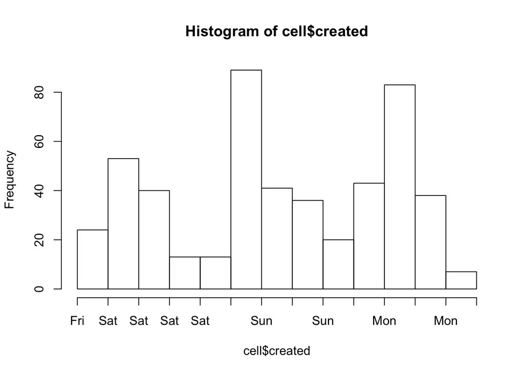

```r
LandRover=TweetFrame("#landrover",500,'2020-01-01')

cell=LandRover

hist(cell$created,breaks=15,freq=TRUE)
```

```r
mfv(as.integer(diff(cell$created)))
```

```
## [1] 101
```

```r
myStopwords = c(stopwords(source = "snowball"), stopwords(source = "stopwords-iso"),
                stopwords(source = "smart"))

myStopwords = unique(myStopwords)

Corpus.cell = Corpus(VectorSource(cell$text))
myCorpus=Corpus.cell
myStopwords <- stopwords('english')

myCorpus2 <- tm_map(myCorpus, removeWords, myStopwords)

myCorpus2 <- tm_map(myCorpus2, removePunctuation)

myCorpus2 <- tm_map(myCorpus2, removeNumbers)

myCorpus2 <- tm_map(myCorpus2, tolower)

TDM_cell <- TermDocumentMatrix(myCorpus2, control = list(minWordLength = 5))
dim(TDM_cell)
```

```
## [1] 1524  500
```

```r
# Create Word Cloud

inspect(TDM_cell[1:10,21:30])
```

```
## <<TermDocumentMatrix (terms: 10, documents: 10)>>
## Non-/sparse entries: 7/93
## Sparsity           : 93%
## Maximal term length: 15
## Weighting          : term frequency (tf)
## Sample             :
##                  Docs
## Terms             21 22 23 24 25 26 27 28 29 30
##   armrest          0  0  0  0  0  0  0  0  0  0
##   box…             0  0  0  0  0  0  0  0  0  0
##   centre           0  0  0  0  0  0  0  0  0  0
##   cool             0  0  0  0  0  0  0  0  0  0
##   coolerwarmer     0  0  0  0  0  0  0  0  0  0
##   discoverysports  0  0  0  0  0  0  0  0  0  0
##   heat             0  0  0  0  0  0  0  0  0  0
##   keep             0  0  0  0  0  0  0  0  0  0
##   landrover        1  1  0  1  0  1  1  0  2  1
##   landroverza      0  0  0  0  0  0  0  0  0  0
```

[figure not shown]

```r
freeq <- sort(rowSums(as.matrix(TDM_cell)), decreasing=TRUE)
myNames <- names(freeq)
d <- data.frame(word=names(freeq), freq=freeq)
wordcloud(d$word, d$freq, min.freq=10)
```

### Company Two: Mercedes

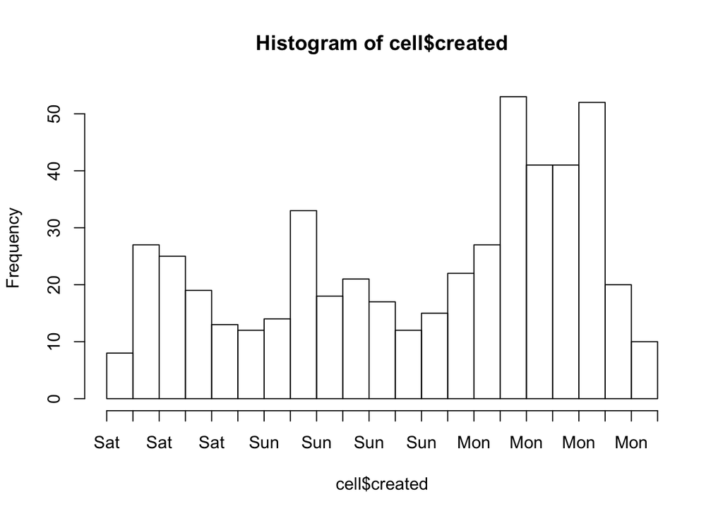

```r
Mercedes=TweetFrame("#mercedes",500,'2020-01-01')

cell=Mercedes

hist(cell$created,breaks=15,freq=TRUE)
```

```r
mfv(as.integer(diff(cell$created)))
```

```
## [1] 41
```

```r
myStopwords = c(stopwords(source = "snowball"), stopwords(source = "stopwords-iso"),
                stopwords(source = "smart"))

myStopwords = unique(myStopwords)

Corpus.cell = Corpus(VectorSource(cell$text))
myCorpus=Corpus.cell
myStopwords <- stopwords('english')

myCorpus2 <- tm_map(myCorpus, removeWords, myStopwords)

myCorpus2 <- tm_map(myCorpus2, removePunctuation)

myCorpus2 <- tm_map(myCorpus2, removeNumbers)

myCorpus2 <- tm_map(myCorpus2, tolower)

TDM_cell <- TermDocumentMatrix(myCorpus2, control = list(minWordLength = 5))
dim(TDM_cell)
```

```
## [1] 1923  500
```

```r
# Create Word Cloud

inspect(TDM_cell[1:10,21:30])
```

```
## <<TermDocumentMatrix (terms: 10, documents: 10)>>
## Non-/sparse entries: 10/90
## Sparsity           : 90%
## Maximal term length: 17
## Weighting          : term frequency (tf)
## Sample             :
##                    Docs
## Terms               21 22 23 24 25 26 27 28 29 30
##   beautiful          0  0  0  0  0  0  0  0  0  0
##   car                0  0  0  0  0  0  0  0  0  0
##   day                0  0  0  0  0  0  0  0  0  0
##   dirty              0  0  0  0  0  0  0  0  0  0
##   fmike              0  0  0  0  0  0  0  0  0  0
##   hello              0  0  0  0  0  0  0  0  0  0
##   httpstcootfqcrcsy  0  0  0  0  0  0  0  0  0  0
##   httpstcowjcjslp    0  0  0  0  0  0  0  0  0  0
##   mercedes           1  1  1  1  1  1  1  1  1  1
##   peekboo            0  0  0  0  0  0  0  0  0  0
```

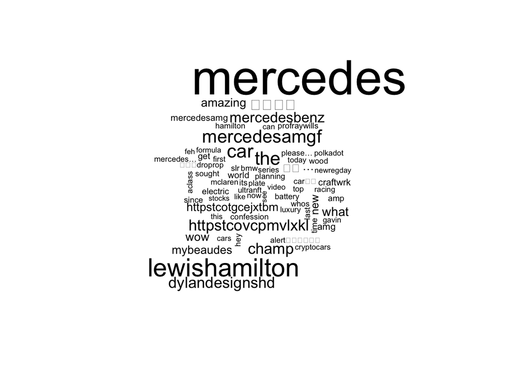

```r
freeq <- sort(rowSums(as.matrix(TDM_cell)), decreasing=TRUE)
myNames <- names(freeq)
d <- data.frame(word=names(freeq), freq=freeq)
wordcloud(d$word, d$freq, min.freq=10)
```

### Company Three: Porsche

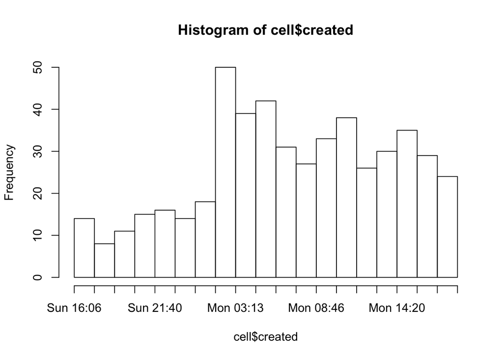

```r
Porsche=TweetFrame("#porsche",500,'2020-01-01')

cell=Porsche

hist(cell$created,breaks=15,freq=TRUE)
```

```r
mfv(as.integer(diff(cell$created)))
```

```
## [1] 2
```

```r
myStopwords = c(stopwords(source = "snowball"), stopwords(source = "stopwords-iso"),
                stopwords(source = "smart"))

myStopwords = unique(myStopwords)

Corpus.cell = Corpus(VectorSource(cell$text))
myCorpus=Corpus.cell
myStopwords <- stopwords('english')

myCorpus2 <- tm_map(myCorpus, removeWords, myStopwords)
myCorpus2 <- tm_map(myCorpus2, removePunctuation)
myCorpus2 <- tm_map(myCorpus2, removeNumbers)
myCorpus2 <- tm_map(myCorpus2, tolower)
TDM_cell <- TermDocumentMatrix(myCorpus2, control = list(minWordLength = 5))
dim(TDM_cell)
```

```
## [1] 1852  500
```

```r
# Create Word Cloud

inspect(TDM_cell[1:10,21:30])
```

```
## <<TermDocumentMatrix (terms: 10, documents: 10)>>
## Non-/sparse entries: 5/95
## Sparsity           : 95%
## Maximal term length: 15
## Weighting          : term frequency (tf)
## Sample             :
##                  Docs
## Terms             21 22 23 24 25 26 27 28 29 30
##   esports          0  0  0  0  0  0  0  0  0  0
##   jkrogers…        0  0  0  0  0  0  0  0  0  0
##   main             0  0  0  0  0  0  0  0  0  0
##   mitchelldejong   0  0  0  0  0  0  0  0  0  0
##   montreal         0  0  0  0  0  0  0  0  0  0
##   pesc             0  0  0  0  0  0  0  0  0  0
##   porsche          2  0  1  0  0  1  0  1  1  0
##   porschenewsroom  0  0  0  0  0  0  0  0  0  0
##   race             0  0  0  0  0  0  0  0  0  0
##   supercup         0  0  0  0  0  0  0  0  0  0
```

[figure not shown]

```r
freeq <- sort(rowSums(as.matrix(TDM_cell)), decreasing=TRUE)
myNames <- names(freeq)
d <- data.frame(word=names(freeq), freq=freeq)
wordcloud(d$word, d$freq, min.freq=10)
```